# COMPSCIX 415.2 Homework 5/Midterm

```r
sales_over_500<-txhousing %>%
  group_by(city)%>%
  filter(sales>=500)

sales_over_500
```

```
## # A tibble: 1,889 x 9
## # Groups:   city [14]
##    city       year month sales   volume median listings inventory  date
##    <chr>     <int> <int> <dbl>    <dbl>  <dbl>    <dbl>     <dbl> <dbl>
##  1 Arlington  2000     8   507 60875199 103400     1417       3.5 2001.
##  2 Arlington  2001     5   536 69878959 114400     1592       3.7 2001.
##  3 Arlington  2001     6   534 67744182 108500     1627       3.8 2001.
##  4 Arlington  2001     7   500 66350350 116000     1693       3.9 2002.
##  5 Arlington  2001     8   505 65080743 113600     1616       3.7 2002.
##  6 Arlington  2002     5   503 67240236 116100     1741       3.9 2002.
##  7 Arlington  2002     7   509 66954143 119100     1925       4.4 2002.
##  8 Arlington  2003     5   502 67131982 118000     2544       5.9 2003.
##  9 Arlington  2003     7   524 73194692 123500     2799       6.5 2004.
## 10 Arlington  2003     8   531 72397143 123900     2801       6.4 2004.
## # … with 1,879 more rows
```

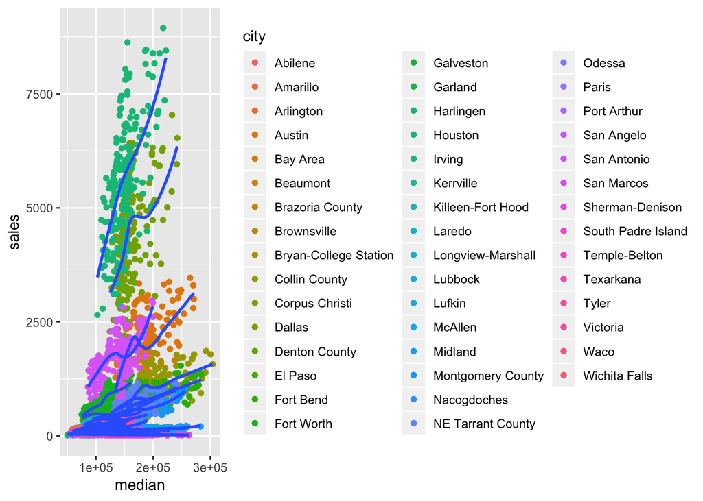

```r
ggplot(data=txhousing, mapping = aes(x = median, y = sales))+
 geom_point(aes(color=city))+
 geom_smooth(aes(group=city),se = FALSE)
```

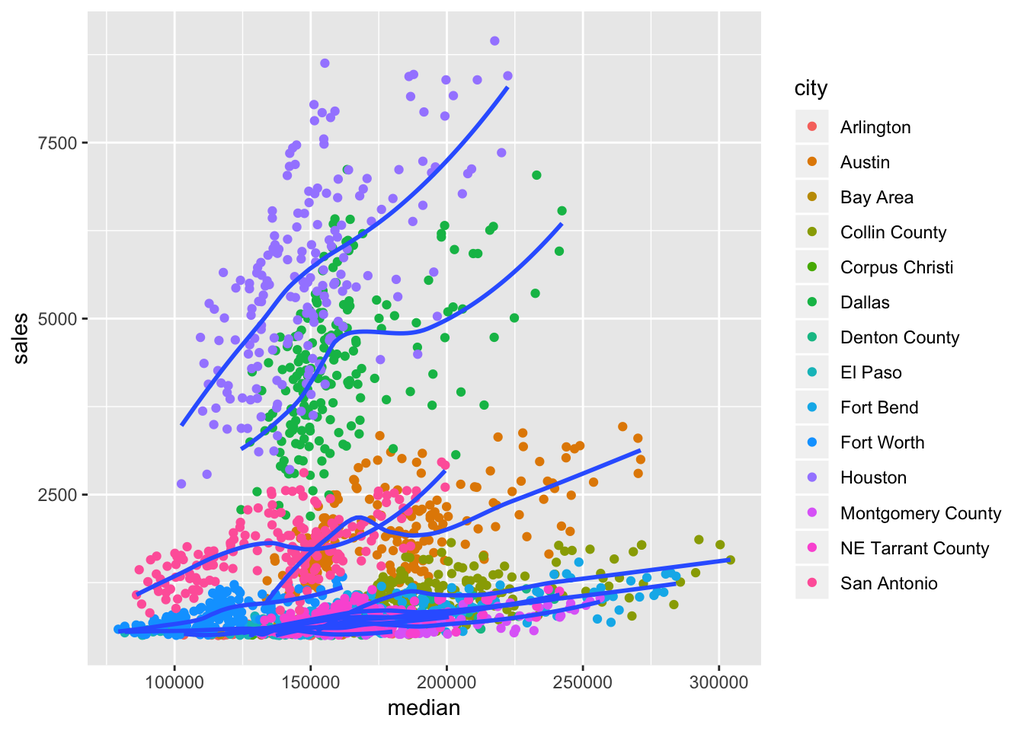

```r
ggplot(data=sales_over_500, mapping = aes(x = median, y = sales))+
 geom_point(aes(color=city))+
 geom_smooth(aes(group=city),se = FALSE)
```

Yes I see a significant positive correlation between median and sales when sales is over 500. • Any cities that stand out that you’d want to investigate further?

Houston shows stands out the most portive correlation between median and sales numebers and we need to investigate further

• Why might we want to filter out all cities and months with sales less than 500?

```r
sales_less_than_500<-txhousing %>%
  group_by(city)%>%
  filter(sales<500)

sales_less_than_500
```

```
## # A tibble: 6,145 x 9
## # Groups:   city [42]
##    city     year month sales   volume median listings inventory  date
##    <chr>   <int> <int> <dbl>    <dbl>  <dbl>    <dbl>     <dbl> <dbl>
##  1 Abilene  2000     1    72  5380000  71400      701       6.3 2000
##  2 Abilene  2000     2    98  6505000  58700      746       6.6 2000.
##  3 Abilene  2000     3   130  9285000  58100      784       6.8 2000.
##  4 Abilene  2000     4    98  9730000  68600      785       6.9 2000.
##  5 Abilene  2000     5   141 10590000  67300      794       6.8 2000.
##  6 Abilene  2000     6   156 13910000  66900      780       6.6 2000.
##  7 Abilene  2000     7   152 12635000  73500      742       6.2 2000.
##  8 Abilene  2000     8   131 10710000  75000      765       6.4 2001.
##  9 Abilene  2000     9   104  7615000  64500      771       6.5 2001.
## 10 Abilene  2000    10   101  7040000  59300      764       6.6 2001.
## # … with 6,135 more rows
```

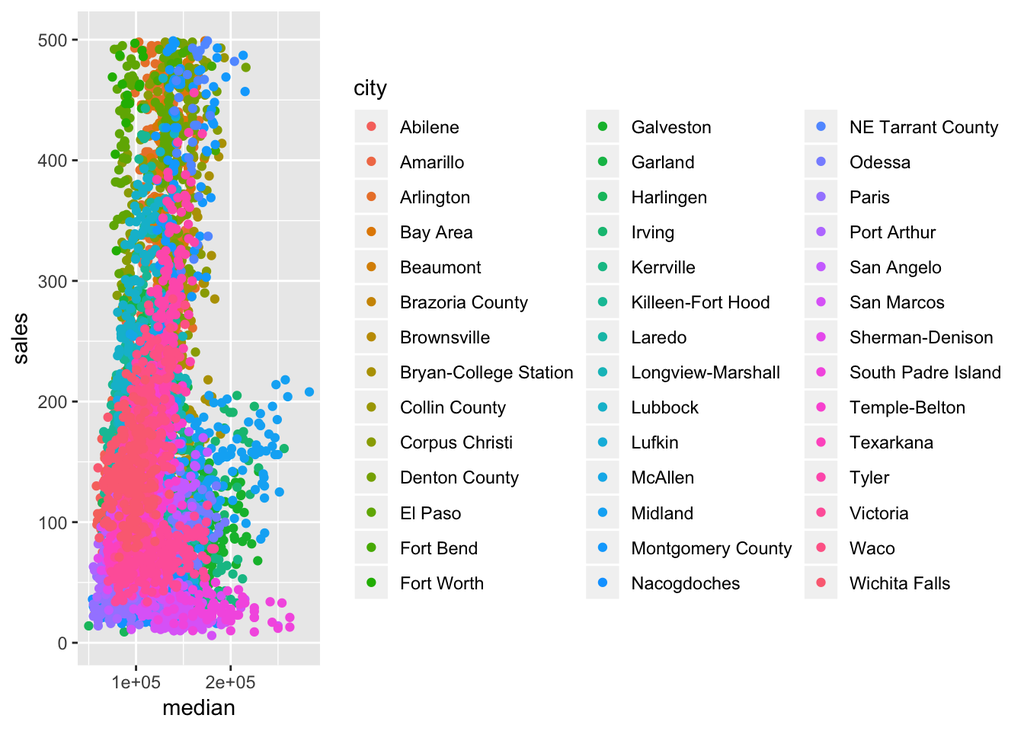

```r
ggplot(data=sales_less_than_500, mapping = aes(x = median, y = sales))+
 geom_point(aes(color=city))+
 geom_smooth(aes(group=city),se = FALSE)
```

It is nenessary to investigate all sales less than 500 because there might be correlation between median and sales numbers ##*Git and Github (1.5 points)*